# Matrix as change of basis

### **NOTES ON STATISTICS, PROBABILITY and MATHEMATICS**

### The Matrix as a Change of Basis:

We can consider $A$ as transformation $A: \mathbb R^n \rightarrow \mathbb R^m$ for an $m \times n$ matrix.

From the [Kahn Academy series](https://www.khanacademy.org/math/linear-algebra/alternate-bases/change-of-basis/v/linear-algebra-change-of-basis-matrix):

If we have a basis, $B=\{\vec v_1, \vec v_2, \dots, v_k\}$ the coordinates of a vector $\vec a$ with respect to this basis can be expressed as:

$\large [\vec a]_B=\begin{bmatrix}c_1\\c_2\\\vdots\\c_k\end{bmatrix}$

Equivalently,

$\large c_1\vec v_1 + c_2\vec v_2+\dots+c_k \vec v_k=\underset{\color{blue}{\text{change of basis matrix 'C'}}}{\underbrace{\color{blue}{\begin{bmatrix}\vert & \vert & &\vert \\v_1&v_2&\dots&v_k\\\vert&\vert&&\vert\end{bmatrix}}}}\begin{bmatrix}c_1\\c_2\\\vdots\\c_k\end{bmatrix}$

So

$$\Large\bbox[yellow, 10px]{ \text{C}\quad
[\vec a]_B \quad=\quad [\vec a]_{\text{standard}}}$$

The **change of basis matrix** is the matrix with the basis vectors as columns.

Similarly we can solve for the coordinates of a vector with respect to a basis: If we know that the vector $\vec d = \begin{bmatrix}8\\-6\\2\end{bmatrix}$ is in the span of the $\mathbb R^2$ basis $\vec v_1 = \begin{bmatrix}1\\2\\3\end{bmatrix}$ and $\vec v_2 = \begin{bmatrix}1\\0\\1\end{bmatrix}$, we can solve $\text{C}\,\color{red}{ [\vec d]_B}=\vec d,$ as a system of linear equations (expanded matrix).

If $\text{C}$ is invertible (i.e. it is square and with linearly independent column vectors - a given in a basis), the span of $\text{C}$ is $\mathbb R^n$, and:

$$\large \text{C}^{-1} \quad \text{C}\quad
[\vec a]_B= \text{C}^{-1} \quad\vec a$$

and hence,

$$\bbox[yellow, 10px]{\Large[\vec
a]_B\quad= \quad\text{C}^{-1} \quad[\vec
a]_{\text{standard}}}$$

In general,

$$\bbox[yellow, 10px]{\Large[\vec
a]_{\text{new coord.}}\quad= \quad\text{C}^{-1} \quad[\vec a]_{\text{old
coord}}}\tag{1}$$

$\large \bf A\vec x$ is a **linear** transformation (**transformation = mapping or function operating on vectors expressed as $T(\vec x)$**) of $\vec x$ *with $\vec x$* expressed in the standard basis: $T(\vec x) = A\vec x.$ But there are multiple different bases. The mapping afforded by the transformation on $[\vec x]_B$ will be $[T(\vec x)]_B.$ We can find a matrix $\text{D}$, such that
$$[T(\vec x)]_B= \text{D} [\vec
x]_B\tag{2}$$

$\text{D}$ is the **transformation matrix for $T$ with respect to $B$.**

Now, $T(\vec x) = A\vec x$, and replacing in Eq.2:

$$[T(\vec x)]_B=[A\vec x]_B =\text{D}
[\vec x]_B$$

From Eq.1, $[A\vec x]_B$ can be expressed as:

$$[A\vec x]_B= \text{C}^{-1} A\vec
x$$

at the same time $\vec x = \text{C}[\vec x]_B.$ Therefore,

$$\Large\bbox[yellow, 10px]{\text{D}\quad
[\vec x]_B\quad=\quad [A\vec x]_B \quad= \quad \text{C}^{-1}\quad
A\quad \text{C}\quad[\vec x]_B}$$

We can also see that

$$\text{D}\quad\text{C}^{-1}=\text{C}^{-1}\quad A
\quad \text{C}\quad\text{C}^{-1}$$

or

$$\text{C}\quad\text{D}\quad\text{C}^{-1}=\text{C}\quad\text{C}^{-1}\quad
A\quad \text{C}\quad\text{C}^{-1}$$

Hence,

$$\Large A = \text{C D
C}^{-1}$$

Summary diagram:

$\require{AMScd}$
$$\begin{CD}
\text{STD. COORD: }\vec x @>\text{A}>> T(\vec x)\\
@V V \text{C inv} V @VV \text{C inv} V\\
\text{COORD wrt B: }[\vec x]_B @>>\text{D}> T[(\vec x)]_B
\end{CD}$$

From [this lecture by Norm Wildberger](https://youtu.be/yAb12PWrhV0).

Any point on the plane is expressed differently by Emily $\vec e=\begin{bmatrix}\bf \color{green}{e_1} \\ \bf \color{blue}{e_2 }\end{bmatrix}$ compared to Frank $\vec f=\begin{bmatrix} \bf \color{orange}{f_1} \\ \bf \color{brown}{f_2} \end{bmatrix}$.

So we can say that Frank’s basis vector $\vec f_1=\begin{bmatrix}\color{orange}{1_{\text{f}}}\\\color{brown}{0_{\text{f}}}\end{bmatrix}$ is $\vec f_1 = 5 \, \color{green}{e_1} - 2 \, \color{blue}{e_2}$; and Frank’s basis vector $\vec f_2=\begin{bmatrix}\color{orange}{0_\text{f}}\\\color{brown}{1_\text{f}}\end{bmatrix}$ is $\vec f_2 = 1.5 \, \color{green}{e_1} + 2.5 \, \color{blue}{e_2}$ from Emily’s perspective.

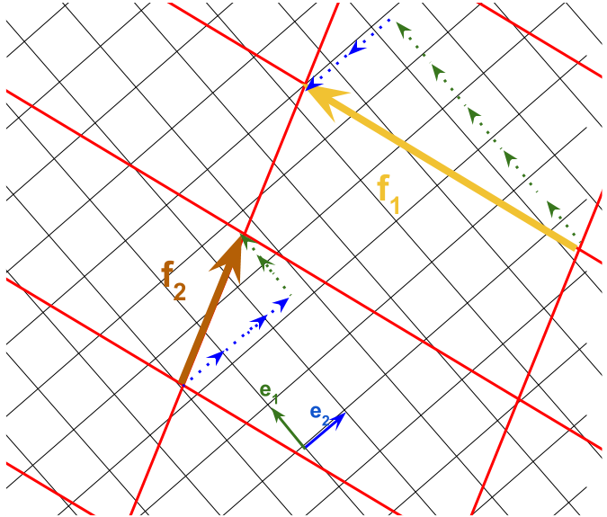

Or we can say that the basis vectors in Frank’s system will be seen from Emily’s perspective as:

$$\left(\vec f_1\right)_{\vec
e}=\begin{bmatrix}\color{green}{5} & \color{green}{1.5} \\
\color{blue}{-2} &
\color{blue}{2.5}\end{bmatrix}\,\begin{bmatrix}\color{orange}{1_{\text{f}}}\\\color{brown}{0_{\text{f}}}\end{bmatrix}=\begin{bmatrix}{\color{green}{5}\\\color{blue}{-2}}\end{bmatrix}$$

and

$$\left(\vec f_2\right)_{\vec
e}=\begin{bmatrix}\color{green}{5} & \color{green}{1.5} \\
\color{blue}{-2} &
\color{blue}{2.5}\end{bmatrix}\,\begin{bmatrix}\color{orange}{0_{\text{f}}}\\\color{brown}{1_{\text{f}}}\end{bmatrix}=\begin{bmatrix}{\color{green}{1.5}\\\color{blue}{2.5}}\end{bmatrix}$$

So in the columns of $\bf A =\begin{bmatrix}\color{green}{5} & \color{green}{1.5} \\ \color{blue}{-2} & \color{blue}{2.5}\end{bmatrix}$ we have stored how the basis vectors in Frank’s system are expressed in Emily’s basis:

$$\bf A =\begin{bmatrix}\color{green}{5}
& \color{green}{1.5} \\ \color{blue}{-2} &
\color{blue}{2.5}\end{bmatrix} = \begin{bmatrix}\vert & \vert \\
(\vec f_1)_{\vec e} & (\vec f_2)_{\vec e} \\ \vert & \vert
\end{bmatrix}$$

If we were to express in Emily’s system some other vector initially given in Frank’s system we would just have to perform the operation:

$$\begin{align}\begin{bmatrix}\bf
y_{1e}\\\bf{y_{2e}}\end{bmatrix}&=
\begin{bmatrix}\color{green}{5} & \color{green}{1.5} \\
\color{blue}{-2} & \color{blue}{2.5}\end{bmatrix}\begin{bmatrix}\bf
x_{1f}\\\bf x_{2f}\end{bmatrix}\\[2ex]
&=\bf
x_{1f}\begin{bmatrix}\color{green}{5}\\\color{blue}{-2}\end{bmatrix} +
\bf
x_{2f}\begin{bmatrix}\color{green}{1.5}\\\color{blue}{2.5}\end{bmatrix}
\end{align}$$

The thing to note is that $\bf x_{1f}$ will multiply the first column in the matrix to contribute to $\bf y$ (the first basis vector contribution); and $\bf x_{2f}$ will multiply the second column vector to contribute to $\bf y$ (the second basis vector contribution, expressed in Emily’s language).

Clearly we have just made up the equivalence between vector basis in between systems, and any other matrix $\bf A$ would have served the purpose. Therefore we can say that the operation $\bf Ax = b$ is the equivalent of a change of basis: $\begin{bmatrix}{\bf y_{1e} \\ \bf y_{2e}}\end{bmatrix}$ is $\begin{bmatrix}{\bf x_{1f} \\ \bf x_{2f}}\end{bmatrix}$ viewed from Emily’s perspective!

So is the system of equations:

$$\begin{align}
5{\bf x_{1f}} + 1.5\bf{x_{2f}}&=\bf{y_{1e}}\\
-2{\bf x_{1f}} + 2.5 \bf{x_{2f}} &=\bf{y_{2e}}
\end{align}$$

Can we express Emily’s vectors from Frank’s perspective? Yes:

$$\begin{align}
\frac{5}{31}{\bf y_{1e}} \frac{-3}{31}\bf{y_{2e}}&=\bf{x_{1f}}\\
\frac{4}{31}{\bf y_{1f}} + \frac{10}{31} \bf{y_{2e}} &=\bf{x_{2f}}
\end{align}$$

or

$$\begin{bmatrix}\color{green}{5} &
\color{green}{1.5} \\ \color{blue}{-2} &
\color{blue}{2.5}\end{bmatrix}^{-1}=\begin{bmatrix}\color{orange}{\frac{5}{31}}&\color{orange}{\frac{-3}{31}}\\\color{brown}{\frac{4}{31}}&\color{brown}{\frac{10}{31}}\end{bmatrix}$$

So now we can look at the Emily’s coordinates vector $\begin{bmatrix}\bf y_{1e}\\ \bf y_{1e}\end{bmatrix}$ in Frank’s coordinates:

$$\begin{bmatrix}\color{orange}{\frac{5}{31}}&\color{orange}{\frac{-3}{31}}\\\color{brown}{\frac{4}{31}}&\color{brown}{\frac{10}{31}}\end{bmatrix}\begin{bmatrix}{\bf
y_{1e} \\ y_{1e}}\end{bmatrix}=\begin{bmatrix}{\bf x_{1f} \\ \bf
x_{2f}}\end{bmatrix}$$

Likewise, the basis vectors of Emily with respect to Frank’s are:

$$\left(\vec e_1\right)_{\vec
f}=\begin{bmatrix}\color{orange}{\frac{5}{31}}&\color{orange}{\frac{-3}{31}}\\\color{brown}{\frac{4}{31}}&\color{brown}{\frac{10}{31}}\end{bmatrix}\,\begin{bmatrix}\color{green}{1_{\text{e}}}\\\color{blue}{0_{\text{e}}}\end{bmatrix}=\begin{bmatrix}{\color{orange}{\frac{5}{31}}\\\color{brown}{\frac{4}{31}}}\end{bmatrix}$$

and

$$\left(\vec e_2\right)_{\vec
f}=\begin{bmatrix}\color{orange}{\frac{5}{31}}&\color{orange}{\frac{-3}{31}}\\\color{brown}{\frac{4}{31}}&\color{brown}{\frac{10}{31}}\end{bmatrix}\,\begin{bmatrix}\color{green}{0_{\text{e}}}\\\color{blue}{1_{\text{e}}}\end{bmatrix}=\begin{bmatrix}{\color{orange}{\frac{-3}{31}}\\\color{brown}{\frac{10}{31}}}\end{bmatrix}$$

[Home Page](http://rinterested.github.io/statistics/index.html)

**NOTE: These are tentative notes on different topics for personal use - expect mistakes and misunderstandings.**